# HFTC slides

[figure not shown]

## 20 September 2018

## Machine Learning and Big Data

## Druce Vertes

[figure not shown]

# Agenda

## - Some observations on big data and machine learning

## - What is big data? How is machine learning different from statistics?

## - A roadmap for applying machine learning - code examples, resources

## - Some fun examples

# What machine learning tells you about the person doing it

[figure not shown]

# Thesis: Nothing new under the sun, it's all just fashion, new words, more modern tools for what we always did.

[figure not shown]

# With a healthy dose of title inflation

### - Excel monkey -> Business Intelligence Analyst

### - SQL report jockey -> Data Scientist

### - Forecaster -> Machine learning scientist, AI researcher

### More things change, the more they remain the same

# Antithesis: It's the [Singularity](https://en.wikipedia.org/wiki/Technological_singularity)!

[figure not shown]

# Many ML algorithms go back decades

### We had most of the pieces but recently hit takeoff velocity:

### - Better hardware (especially GPUs)

### - Better algorithms (efficient backpropagation, new neural network architectures)

### - Much more data from digital everything

# A virtuous cycle

### - [AlexNet](https://adeshpande3.github.io/The-9-Deep-Learning-Papers-You-Need-To-Know-About.html) (2012), a first sign of AI spring, very successful image classification deep NN

### → More research

### → More deployed apps, speech recognition, image recognition, machine translation, self-driving cars, robots,

### → More data, more investment in hardware and algos

### → Huge advances in many applications

### → Huge growth in investment in research, better hardware, perpetuating the cycle

### → General AI and beyond? (Or a new AI winter?)

# An Evolutionary Process

[figure not shown]

Synthesis -

[figure not shown]

# Synthesis

### A big leap forward in machine learning in a few years

### Now anyone can do stuff that a few years ago you needed to be a PhD with a Google cluster to do

### Maybe not The Singularity but rapid improvement via an evolutionary process that we don't know where it will ultimately lead.

Small quantitative changes add up, and eventually reach a tipping point where you see a large qualitative change, like water turning to ice.

*“It is said that there are no sudden changes in nature, and the common view has it that when we speak of a growth or a destruction, we always imagine a gradual growth or disappearance. Yet we have seen cases in which the alteration of existence involves not only a transition from one proportion to another, but also a transition, by a sudden leap, into a … qualitatively different thing; an interruption of a gradual process, differing qualitatively from the preceding, the former state”*

*G. W. F. Hegel (1770-1831)*

German philosopher, first to write about the hype cycle and the tipping point

# "If we want things to stay as they are, things will have to change." -- The Leopard

# "If we want things to stay the same, we (IT folks) will have to change"

# What is Machine Learning?

[figure not shown]

## Data science

### - Anything involving data: collecting, scrubbing, structuring, feature engineering, visualization

## Machine learning

### - Algorithms that learn from data without explicit programming

## Deep learning

### - Many machine learning algos (neural net layers) trained end to end on a complex task

### - Human like performance in a hard or uncertain domain: computer vision, natural language, games, self-driving cars

### - Often outperforms humans, but (for now) in a narrow domain, stable, non-adversarial context

## Strong general AI

### - Human-like performance in broad, highly variable, adversarial context

### - Still a pipe dream:

### - We still [segregate robots](https://www.seattletimes.com/business/amazon/amazon-has-patented-a-system-that-would-put-workers-in-a-cage-on-top-of-a-robot/) on factory floor for safety

### - Algorithms still struggle in messy real world situations like self-driving cars

# Exponential data requirements:

### - Machine learning: simple algos can do nonlinear prediction with hundreds or thousands of data points

### - Deep learning: typically millions of data points

### - General AI ??? billions and billions ??? (Carl Sagan voice)

# Machine Learning = Statistics For Street Fighting

## Statistics

[figure not shown]

## Machine Learning

[figure not shown]

# When in doubt, use brute force - Ken Thompson

[figure not shown]

# I do nothing that a man of unlimited funds, superb physical endurance, and maximum scientific knowledge could not do. - Batman

# It's sometimes difficult to think clearly when you're strapped to a printing press. - also Batman

[figure not shown]

# Statistics:

## Descriptive + inferential statistics:

## - What can we say about data that's true?

## - What can we infer about future data?

# Machine Learning:

## How can I predict as accurately as possible, with unconstrained computing resources and data?

# Statistical prediction and inference - simple regression

## - You have some data

## - You fit a line, get a slope and an intercept

## - Get some analysis of variation - ANOVA

```python
import plotly
from plotly.offline import download_plotlyjs, init_notebook_mode, plot, iplot
from plotly.graph_objs import *
from plotly.figure_factory import create_table
init_notebook_mode(connected=True)

import numpy as np
import pandas as pd
import scipy

import statsmodels
import statsmodels.api as sm
from statsmodels.formula.api import ols

# create a data set, sin wave plus random noise
nobs = 4000
x = np.linspace(0, 6*np.pi, num=nobs)
y = -np.cos(x) + x*0.05 + np.random.normal(0, 0.25, nobs)
z = np.sin(x) +  x*0.05 + np.random.normal(0, 0.25, nobs)

df = pd.DataFrame({'x' : x,'y': y,'z': z})

# chart it

def mychart(*args):

    # pass some 2d n x 1 arrays, x, y, z

    # 1st array is independent vars
    # reshape to 1 dimensional array
    x = args[0].reshape(-1)

    # following are dependent vars plotted on y axis
    data = []
    for i in range(1, len(args)):
        data.append(Scatter(x=x,
                            y=args[i].reshape(-1),
                            mode = 'markers',
                            marker = dict(size = 2)
                           ))

    layout = Layout(
        autosize=False,
        width=800,
        height=600,
        yaxis=dict(
            autorange=True))

    fig = Figure(data=data, layout=layout)

    return iplot(fig) # , image='png' to save notebook w/static image
```

```python
mychart(x,y)
```

[interactive chart not shown]

```python
#table = create_table(df)
#iplot(table, filename='mydata')

# Very Important
### These are  *in-sample* statistics on the training data
### Hence the disclaimer

formula = 'y ~ x'
model = ols(formula, df).fit()
ypred = model.predict(df)
```

```python
model.summary()
```

OLS Regression Results

| Dep. Variable: | y | R-squared: | 0.113 |
| --- | --- | --- | --- |
| Model: | OLS | Adj. R-squared: | 0.113 |
| Method: | Least Squares | F-statistic: | 508.9 |
| Date: | Sat, 22 Sep 2018 | Prob (F-statistic): | 3.66e-106 |
| Time: | 10:50:05 | Log-Likelihood: | -4536.0 |
| No. Observations: | 4000 | AIC: | 9076. |
| Df Residuals: | 3998 | BIC: | 9089. |
| Df Model: | 1 |  |  |
| Covariance Type: | nonrobust |  |  |

|  | coef | std err | t | P>\|t\| | [0.025 | 0.975] |
| --- | --- | --- | --- | --- | --- | --- |
| Intercept | 0.0147 | 0.024 | 0.616 | 0.538 | -0.032 | 0.061 |
| x | 0.0493 | 0.002 | 22.558 | 0.000 | 0.045 | 0.054 |

| Omnibus: | 2555.490 | Durbin-Watson: | 0.228 |
| --- | --- | --- | --- |
| Prob(Omnibus): | 0.000 | Jarque-Bera (JB): | 226.972 |
| Skew: | 0.016 | Prob(JB): | 5.17e-50 |
| Kurtosis: | 1.833 | Cond. No. | 21.9 |

Warnings:  
[1] Standard Errors assume that the covariance matrix of the errors is correctly specified.

```python
mychart(x,y,np.array(ypred))
```

[interactive chart not shown]

# Potential pitfalls of the OLS model

### You have to know what you are doing

### Transform data to linear + normal error, few predictors

### Doesn't work well with many noisy predictors

## For traditional statistical inference, you want

- A valid, complete *a priori* linear model
- Normally distributed errors

## Things go awry if your data does not match assumptions of OLS

- If your model is not correctly specified, your regression line may not be as predictive as it should be.
- If you don't have normally distributed errors, your p-values and inference about future distributions are wrong because your errors are not random.
- (Even if future is like the past (stationarity))

# Violations of assumptions of OLS: Anscombe's Quartet

### These all have the same slope, intercept, R-squared

[figure not shown]

### You can take this further and construct crazy stuff

### The Datasaurus Dirty Dozen

[figure not shown]

## You need to know what you are doing.

- Visualize your raw data and errors
- Sanity-check your model
- Use appropriate tests to avoid violations of assumptions of OLS:
  - Nonlinearity
  - Heteroskedascisity
  - Autocorrelation
  - Multicollinearity
  - Other non-normality of errors

If you don't have a good linear model, you need to find a better model, transform the data, add variables. If your data violates the assumptions of OLS, you need to understand why and fix it. You can't just throw data at statistical models without knowing what you're doing.

# "With four parameters you can fit an elephant to a curve, with five you can make him wiggle his trunk" - John von Neumann

[figure not shown]

# OLS is not very good when you throw a lot of predictors at it, and don't have a LOT of data

### The more predictors you have, the more outliers you have

### As you add predictors, you need exponentially more data

### With e.g. 10 predictors, you need a LOT of data

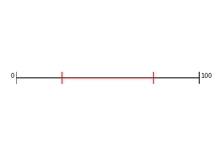

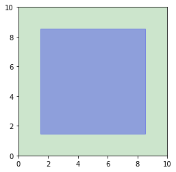

```python
# visualizing how everything is an outlier when you add dimensions
# curse of dimensionality

import matplotlib.pyplot as plt

# set up the figure
fig = plt.figure()
ax = fig.add_subplot(111)
ax.set_xlim(0,11)
ax.set_ylim(0,11)

# draw lines
xmin = 0
xmax = 10
y = 5
height = 1

plt.hlines(y, xmin, xmax)
plt.hlines(y, 2.5, 7.5, color='r')

plt.vlines(xmin, y - height / 2., y + height / 2.)
plt.vlines(xmax, y - height / 2., y + height / 2.)
plt.vlines(2.5, y - height / 2., y + height / 2., color='r')
plt.vlines(7.5, y - height / 2., y + height / 2., color='r')

# add numbers
plt.text(xmin - 0.1, y, '0', horizontalalignment='right')
plt.text(xmax + 0.1, y, '100', horizontalalignment='left')
plt.axis('off')
plt.show()

fig = plt.figure()
ax = fig.add_subplot(111, aspect='equal')
plt.axis('on')
#plt.axes().set_aspect('equal', 'datalim')

offset = np.sqrt(50)/2

ax.set_xlim(0,10)
ax.set_ylim(0,10)

# (or if you have an existing figure)
# fig = plt.gcf()
# ax = fig.gca()

square1 = plt.Rectangle((0, 0), width=10, height=10, color='g', alpha=0.2)
square2 = plt.Rectangle((5-offset, 5-offset), width=offset*2, height=offset*2, color='blue', alpha=0.3)

ax.add_artist(square1)
ax.add_artist(square2)


plt.show()
```

```python
sz = 0.5 ** (1/3)
start = (1-sz)/2
end = start + sz
print(start)
print(end)
data = [
    Mesh3d(
        x = [start, start, end, end, start, start, end, end],
        y = [start, end, end, start, start, end, end, start],
        z = [start, start, start, start, end, end, end, end],
        colorscale = [[0, 'rgb(255, 0, 255)'],
                    [0.5, 'rgb(0, 255, 0)'],
                      [1, 'rgb(0, 0, 255)']],
        intensity = [0, 0.142857142857143, 0.285714285714286,
                     0.428571428571429, 0.571428571428571,
                     0.714285714285714, 0.857142857142857, 1],
        i = [7, 0, 0, 0, 4, 4, 6, 6, 4, 0, 3, 2],
        j = [3, 4, 1, 2, 5, 6, 5, 2, 0, 1, 6, 3],
        k = [0, 7, 2, 3, 6, 7, 1, 1, 5, 5, 7, 6],
        name='y',
        showscale=True
    )
]
layout = Layout(
    width=800,
    height=600,
    xaxis=plotly.graph_objs.layout.XAxis(
        title='x',
    ),
    yaxis=plotly.graph_objs.layout.YAxis(
        title='y',
        range=[0, 1]
    )
)
fig = Figure(data=data, layout=layout)
iplot(fig, filename='3d-mesh-cube-python')
```

```
0.1031497370079501
0.8968502629920498
```

[interactive chart not shown]

- When you increase the number of dimensions, most of the data are outliers
  - Even if you increase the amount of data! Doesn't help
- Looked at another way, if 10% of your data on a dimension is an outlier:
  - after 7 dimensions, most of your data is an outlier on some dimension (1-0.9^7)

```python
x1 = [n for n in range(1,50)]
y1 = [(0.9 ** n) for n in range(1,50)]
pd.DataFrame({'x' : x1, 'y' : y1})

mychart(np.array(x1), np.array(y1))
```

[interactive chart not shown]

- Suppose you want nonlinearity, 3 inflection points in each direction, 3 predictors, all interactions

[figure not shown]

- Number of predictors rises exponentially as you increase degree of nonlinearity (I want to say C(deg+n, deg) but doesn't look right, left as an exercise)
- Data you need to maintain significance as you increase number of predictors is (I think) exponential on that number

# Machine Learning: how you predict when you are no longer constrained by

### Data size - think about how you would predict if you had unlimited data

### Computational complexity - think about how you would predict if you had unbounded computation capacity

### Turns out you can often predict a bit better than OLS

# 3 things ML *generally* offers

## - Implicit predictor selection - works OK with many predictors

## - Robustness -- reasonable ways to avoid chasing outliers

## - Ability to fine-tune bias-variance tradeoff (Bullets above - complexity, # of predictors, how much to chase outliers

# 1 key takeaway -

# ML uses out-of-sample prediction error to find optimal bias-variance tradeoff

# If you know what this means and how to do it, you are a machine learning engineer

[figure not shown]

### Train

- Draw a training sample
- Train a machine learning models on training set (as many as you want)
  - Try different algorithms
  - Try different degree of complexity
    - Different degrees of nonlinearity
    - Different degrees of smoothing/regularization (will discuss further)

### Cross-validate

- Draw a *cross-validation set*
- Take your trained models, use them to predict in cross-validation
- Choose the model that performs best in *cross-validation*
- Now, the act of picking a model contaminates the cross-validation set. Your best model is probably pretty good, but it's also probably one that was a little more lucky in cross-validation.

### Evaluate

- Draw a *test set*
- Evaluate the performance of the model in the test set. Since it is effectively out-of-sample data, it's a reasonable estimate of performance to expect in out-of-sample data.

Example

# 3 key points

## 1. [The Bias/Variance Tradeoff](http://scott.fortmann-roe.com/docs/BiasVariance.html)

[figure not shown]

### - High bias: more linear, doesn't chase outliers

### - High variance: more kinky, more susceptible to noise

### - You need to set your squelch filter so it kills the noise but lets the music through

- Run regressions in browser with different models : https://cs.stanford.edu/people/karpathy/convnetjs/demo/regression.html

# The most important chart in machine learning

[figure not shown]

# 2. [The ROC curve](https://en.wikipedia.org/wiki/Receiver_operating_characteristic)

[figure not shown]

# 3. *The firewall principle:* Never make any decision to modify your model using the test set, and never use the training or cross-validation data sets to evaluate its out-of-sample performance.

# Regularization is very important in tuning your model and finding the right bias/variance tradeoff

- An example is L2 regularization in regression
- Instead of minimizing your mean-squared-error, minimize MSE + the sum of the squares of all your model coefficients
- This will tend to shrink your coefficients (and also equalize them). If a coefficient is large, it might be because it's very significant, or it might be because it's an outlier.
- Regularization increases *bias*, when you use the correct amount of it, you get worse fit in-sample, but better fit out-of-sample, because you are not chasing outliers. It makes your model more robust.
- With decision trees, you might use fewer or shallower trees, with ensemble models, you might use fewer models. The point is to make your model simpler, chase fewer outliers, be more robust, generalize better out-of-sample.
- The 2 key things in machine learning are
  - Always pick model that performs best in xval (adjusted for complexity if possible)
  - Worse is better: A lot of innovation in finding ways to make models resistant to outliers (more biased=worse) without impacting out-of-sample performance

# Machine Learning paradigm vs Statistics

| Statistics | Machine learning |
| --- | --- |
| Small data | Need big data for complex models with many variables/kinks |
| Optimize model in-sample error | Optimize cross-validation error |
| Assume linear (or a priori functional form) | Algorithm finds nonlinear model |
| Choose predictors parsimoniously | Algorithm chooses from many predictors and models |
| Optimize as much as possible | Worse is usually better |
| Can't overfit a parsimonious linear model | Find optimal balance between under- and overfitting using regularization |
| Inference: description, prediction, attribution | Focus on prediction - attribution often opaque |
| You need to know what you are doing | You need to know what you are doing |

# Neural Network Model

[figure not shown]

# Random Forest Model (Decision tree ensemble)

[figure not shown]

# Recurrent Neural Network (GRU)

[figure not shown]

# Boosting models are very popular but this one didn't work too well

### Random forest : ensemble of parallel decision trees that are trained in parallel on subsets of the predictors and vote

### Boosted decision trees: ensemble of decision trees that are trained sequentially with increasing weight on incorrectly predicted observations

### Possibly XGBoost is mostly used for classification or possibly needs further tuning

[figure not shown]

# Portfolio example

### - Classify industries into quartiles using Ken French data

### - 0.8 Sharpe, outperforms linear model and S&P (until GFC)

### [Notebook](https://github.com/druce/Machine-learning-for-financial-market-prediction/blob/master/Replicate%20Paper%20by%20Rapach%2C%20Strauss%2C%20Tu%2C%20Zhou-4-Way%20Classification.ipynb)

[figure not shown]

# In statistics, you get not very good predictions and you know why they are not very good (simple model (bias), violations of assumptions of OLS)

# In machine learning, you get very good predictions but you don't know why they are very good ( complex models, opaque attribution)

- People talk about machine learning and complex models they go, ooh, you're data mining, overfitting: In fact, very focused on being robust, not chasing outliers, avoiding overfitting
- You can overfit with linear models when you run many models on small samples and just publish the ones that work.
  - [Power poses - Amy Cuddy](https://www.nytimes.com/2017/10/18/magazine/when-the-revolution-came-for-amy-cuddy.html)
  - [Brian Wansink](https://www.buzzfeednews.com/article/stephaniemlee/brian-wansink-retired-cornell)
  - These practices were widespread, unfortunate academics were penalized not because they were worse, but because they were popular media darlings.
- Data mining is a major problem with traditional statistical methodology when you don't test out-of-sample.
- With adequate data and good methodology you avoid overfitting. Paranoia about data mining and overfitting is 'fighting the last war.'

# ML sometimes needs big data but what do we mean by big data?

## Computational perspective - Big data is where you need to use clusters

- Big data is data that doesn't fit in a box: a single computer's memory
  - Google - canonical example
    - Query gets multiplexed to dozens (100s?) of servers in a cluster, which each contain a shard of the index
    - Results, including excerpts (!) get collected and sorted by relevance
    - SERP gets built and returned in a fraction of a second
    - By employing PageRank and at-the-time novel cluster architecture which caches the entire Internet and its full-text index, Google achieved a quantum leap in web scale Internet services

## You've come a long way, baby: current biggest AWS instance

[figure not shown]

## Big Data = scale-out stack

These days big data has to be *REALLY REALLY BIG* before you *need* a Google cluster/Hadoop cluster approach.

Sometimes it might make sense to use the big data scale-out cluster approach as opposed to scale-up huge instances.

Big data can refer to this type of stack, even if the data is not big data in a Google / Facebook web-scale sense or in a computational sense.

## Data science perspective

## Big data = enough data that you don't worry about having enough data for complex models, don't worry about p-values

Big Data:

- Sufficient data that you aren't constrained in terms of model complexity
- Sufficient data that p-values are irrelevant because you can make them arbitrarily small by increasing sample size.

See also https://datascience.berkeley.edu/what-is-big-data/ - A lot of definitions boiling down to, size of data that was unreasonable in the PC era but tractable in cloud environment. Big enough for machine learning. A lot of people say big data when they mean machine learning, modern predictive analytics.

# Overview of Machine Learning Algorithms

## - Supervised

## - Unsupervised

## - Reinforcement learning

# Supervised Learning

You have labeled data: a sample of ground truth with features and labels. You estimate a model that predicts the labels using the features. Alternative terminology: predictor variables and target variables. You predict the values of the target using the predictors.

- *Regression.* The target variable is numeric.
  - Example: you want to predict the crop yield based on remote sensing data.
  - Algorithms: linear regression, polynomial regression, generalized linear models.
- *Classification.* The target variable is discrete or categorical.
  - Example: you want to detect the crop type that was planted using remote sensing data. Or Silicon Valley’s [“Not Hot Dog”](https://medium.com/@timanglade/how-hbos-silicon-valley-built-not-hotdog-with-mobile-tensorflow-keras-react-native-ef03260747f3) application.
  - Algorithms: Naïve Bayes, logistic regression, discriminant analysis, decision trees, random forests, support vector machines, neural networks of many variations: feed-forward NNs, convolutional NNs, recurrent NNs.

## Unsupervised learning

You have a sample with unlabeled information. No single variable is the specific target of prediction. You want to learn interesting features of the data:

- Clustering. Which of these things are similar?
  - Example: group consumers into relevant psychographics.
  - Algorithms – k-means, hierarchical clustering.
- Anomaly detection. Which of these things are different?
  - Example: credit card fraud detection.
  - Algorithms: k-nearest-neighbor.
- Dimensionality reduction. How can you summarize the data in a high-dimensional data set using a lower-dimensional dataset which captures as much of the useful information as possible (possibly for further modeling with supervised or unsupervised algorithms)?
  - Example: image compression, de-noising
  - Algorithms: principal component analysis (PCA), neural network autoencoders, denoising autoencoders.
- Representation: take a large body of text or movies or songs and create dense vectors describing them.
  - Example: Recommendation engines, natural language processing (NLP)
  - Algorithms: Word2vec, GlOVe

## Reinforcement learning

You might think unlabeled/labeled pretty much covers all the bases.

Reinforcement learning can be viewed as 'meta' supervised learning.

You are presented with a game or real-world task that responds sequentially or continuously to your inputs, and you learn to optimize behavior in the form of a policy function to maximize an objective through trial and error.

- The algorithm goes out and explores the problem space and creates a representation of the space.
- Then it creates a policy to optimize the reward
  - Create a Markov decision matrix that maps the environment to actions - the policy function.
  - Label the matrix with the outcomes that followed.
  - Optimize the matrix by gradient descent.

RL resembles supervised learning but at a higher level.

- Instead of predictors, you have to explore the problem space, collect information, build decision matrix
- Instead of hard labels, a potentially imperfect map from action to outcome
  - You get a big negative reinforcement when you screw up, run a stop sign, run over a pedestrian.
  - You get a positive reinforcement when you navigate to your destination safely.
- From those high level labels, you have to model the game by finding high-level abstractions to represent situations encountered, map them to actions using a policy function, and optimize the policy function based on the outcomes.

It's sufficiently important that nowadays people put it in its own category. (Also this is how you might implement a trading robot).

- https://medium.com/applied-data-science/how-to-build-your-own-alphazero-ai-using-python-and-keras-7f664945c188
- https://medium.com/emergent-future/simple-reinforcement-learning-with-tensorflow-part-0-q-learning-with-tables-and-neural-networks-d195264329d0
- https://www.youtube.com/watch?v=79pmNdyxEGo

# More amazing examples of machine learning -

Vision

- [Image classification](http://cs231n.stanford.edu/)
- [Style transfer](https://www.ostagram.me/static_pages/lenta?order=likes&style_id=563604)
- [Google Quick, Draw!](https://quickdraw.withgoogle.com/)
- [Generating photorealistic images from (essentially) descriptions](https://tcwang0509.github.io/pix2pixHD/?utm_campaign=read_more&utm_medium=blog&utm_source=mybridge)
- [Generating faces using GANs](https://www.theverge.com/2017/10/30/16569402/ai-generate-fake-faces-celebs-nvidia-gan)

Audio

- [Google Duplex conversational agent](https://ai.googleblog.com/2018/05/duplex-ai-system-for-natural-conversation.html?m=1)
- [Spotify Discover Weekly](https://medium.com/s/story/spotifys-discover-weekly-how-machine-learning-finds-your-new-music-19a41ab76efe)

### Natural language

- [Embedding models](https://byterot.blogspot.com/2015/06/five-crazy-abstractions-my-deep-learning-word2doc-model-just-did-NLP-gensim.html) [More on embeddings](https://www.technologyreview.com/s/541356/king-man-woman-queen-the-marvelous-mathematics-of-computational-linguistics/)
- [Issues of bias](https://blog.conceptnet.io/posts/2017/how-to-make-a-racist-ai-without-really-trying/) [Part deux](https://www.insidehighered.com/news/2017/08/21/internet-can-be-brutal-place-women-economics-paper-finds)
- [Fund name generator](http://blog.streeteye.com/blog/2018/02/quantitative-fun-with-fund-names/)

### Reinforcement learning

- [Self-driving cars in the browser](https://janhuenermann.com/projects/learning-to-drive)
- [What your self-driving car sees](https://www.youtube.com/watch?v=BLlwm5Dq7Is)
- [DOTA 2 video](https://www.youtube.com/watch?v=wiOopO9jTZw) [Blog post](https://blog.openai.com/more-on-dota-2/?utm_source=mybridge&utm_medium=blog&utm_campaign=read_more)
- [AlphaGo](https://deepmind.com/blog/alphago-zero-learning-scratch/?utm_source=mybridge&utm_medium=blog&utm_campaign=read_more)

### Other great stuff

- [Mybridge](https://medium.mybridge.co/learn-to-build-a-machine-learning-application-from-top-articles-of-2017-cdd5638453fc)
- [Product Hunt](https://www.producthunt.com/posts/ml-showcase)
- [Convnets in the browser](https://cs.stanford.edu/people/karpathy/convnetjs/)

# Problems

Narrowness and brittleness of deep learning is an Achilles heel - doesn't work well yet in unstable, hostile environments

- Wave a stop sign at a self-driving car and it will stop. Small problems like snow very partly obscuring a stop sign may make it blow through the stop sign. May not work in NY because people will just walk in front of cars. For most deep learning applications you still need a controlled environment. Hopefully we won't get disasters, pushback and decades of AI winter.
- You need a LOT of data for complex models
- Lack of attribution means it's better for low-stakes, high-complexity decisions.
  - If you only predict using empirical data, you may not generalize beyond previously seen situations
  - If you only use theory, model from first principles and don't test against data, your model may be no good
  - You need both theory and empirical observation
  - Machine learning may overemphasize the latter

# Learning resources

This deck is based on a couple of blog posts I did

- https://alphaarchitect.com/2017/09/27/machine-learning-investors-primer/
- https://alphaarchitect.com/2018/06/05/machine-learning-financial-market-prediction-time-series-prediction-sklearn-keras/
- AAblogpost.pdf in this repo

Get the Anaconda distribution and dive in via a course or tutorials

- https://conda.io/docs/user-guide/install/download.html

Python resources

Online books

- http://www.diveintopython.net/
- http://learnpythonthehardway.org/
- http://code.google.com/edu/languages/google-python-class/introduction.html

Tutorials

- http://www.learnpython.org/
- https://code.google.com/p/crunchy/

Other good reads

- http://mirnazim.org/writings/python-ecosystem-introduction/
- http://wordaligned.org/articles/essential-python-reading-list#tocpython-tutorial
- http://jessenoller.com/good-to-great-python-reads/
- https://bitbucket.org/gregmalcolm/python_koans/wiki/Home

Practice

- https://codewars.com - solve simple problems in browser, run test cases, then see how other people solved it, often in a better way

MOOCs

- https://www.datacamp.com/courses/intro-to-python-for-data-science
- https://www.coursera.org/learn/machine-learning
- https://see.stanford.edu/Course/CS229
- https://www.coursera.org/learn/neural-networks
- https://lagunita.stanford.edu/courses/HumanitiesandScience/StatLearning/Winter2015/about (probably too easy for you)
- https://www.coursera.org/learn/probabilistic-graphical-models
- https://www.coursetalk.com/
- https://www.class-central.com/

Frameworks

- http://scikit-learn.org/stable/
- https://keras.io/
- https://www.tensorflow.org/
- https://pytorch.org/

Textbooks

- https://www.amazon.com/Deep-Learning-Python-Francois-Chollet/dp/1617294438/
- https://www.amazon.com/Hands-Machine-Learning-Scikit-Learn-TensorFlow/dp/1491962291/
- https://www.amazon.com/Deep-Learning-Adaptive-Computation-Machine/dp/0262035618/ (theory textbook)
- https://web.stanford.edu/~hastie/Papers/ESLII.pdf
- https://www.amazon.com/Advances-Financial-Machine-Learning-Marcos/dp/1119482089

Blogs/roadmaps

- http://yerevann.com/a-guide-to-deep-learning/
- http://ofir.io/How-to-Start-Learning-Deep-Learning/
- http://colah.github.io/
- http://karpathy.github.io/
- https://machinelearningmastery.com/blog/
- https://towardsdatascience.com/

[Data Science Hierarchy of Needs](https://hackernoon.com/the-ai-hierarchy-of-needs-18f111fcc007)

Data engineering is 80% of the battle.

[figure not shown]

# Alternative Data

- Everyone is selling your data ...
  - [Cell phone location data widely avaiable](https://www.zdnet.com/article/senator-rebukes-carriers-sharing-real-time-location-data/)
  - Free [apps](https://www.reddit.com/r/apple/comments/8vm4u7/psa_edison_email_app_has_the_ability_to_read_user/) mine what you are buying
  - Checkins, expense trackers, loyalty cards? just a way for our HF overlords to get richer
- It's 80%/20% data engineering / data science - this stuff is very resource-intensive
- Data is expensive - $40m was a data budget I heard for big quant HFs like WorldQuant, DE Shaw, Two Sigma, RenTech
- If you think you have a great idea, Jim Simons probably already got there 10 years ago - jk but real edges fleeting, exclusive data / quant edge hard to find/ephemeral/rapidly evolving
- Bifurcation between the real quants like RenTech, Two Sigma which are basically tech firms, and fundamentalists, the latter will probably mostly use alt data research / data from 3rd parties, maybe have a couple of data scientist types internally for projects
- Might be transformative, if all economic activity is instrumented and feeds directly into economic nowcasts / AI-driven markets
- Might be worst of 1984/Brave New World, everyone carrying a telescreen in their pocket which is as addictive as soma.

[figure not shown]

# Alternative Data Landscape - http://alternativedata.org

[figure not shown]

# Alternative Data Landscape - CB Insights

http://mattturck.com/the-new-gold-rush-wall-street-wants-your-data/

[figure not shown]

# Big Data Landscape

Matt Turck - http://mattturck.com/wp-content/uploads/2018/07/Matt_Turck_FirstMark_Big_Data_Landscape_2018_Final.png

[figure not shown]

[2017 JPMorgan alt data report](http://valuesimplex.com/articles/JPM.pdf)

[figure not shown]

# *The forecaster is a gentle man,*

# *With neither sword nor pistol.*

# *He walks along most daintily*

# *Because his balls are crystal.*

- Jupyter Notebook https://github.com/druce/HFTC2018Q3/blob/master/HFTC.ipynb
- git clone https://github.com/druce/HFTC2018Q3 ( Jupyter notebook or HFTC.slides.html )
- Follow [@streeteye](https://twitter.com/StreetEYE) on Twitter
- Blog http://blog.streeteye.com/blog
- https://www.linkedin.com/in/drucevertes/